# Ford GoBike System Data Analysis

## Investigation Overview

In this investigation, we will investigate the trip information of Ford GoBike System. We will visualize the most common trip duration and uses information. We will also take a look at how the trip numbers and duration change with different time of the day, and days of week.

## Dataset Overview

This data consisted of Ford GoBike System of year 2018. Ford GoBike is a bicycle sharing system in the San Francisco Bay Area. There are 1396765 trips information in this dataset.  
The features in the dataset include trip duration (second), trip start and end time, trip start and end location, user type, user birth year and user gender, etc.  
During the data wrangling process, some unneeded variables were removed and some new variables are created to help investigate the dataset effectively.

```python
# import all packages and set plots to be embedded inline
import numpy as np
import pandas as pd
import matplotlib.pyplot as plt
import seaborn as sb

%matplotlib inline

# suppress warnings from final output
import warnings
warnings.simplefilter("ignore")
```

```python
# load in the dataset into a pandas dataframe
df = pd.read_csv('fordgobike_clean.csv')
# Convert 'weekday' to ordered categorical type
weekday_list = ['Monday', 'Tuesday', 'Wednesday', 'Thursday','Friday','Saturday','Sunday']
weekday_order = pd.api.types.CategoricalDtype(ordered=True, categories=weekday_list)
df['weekday'] = df['weekday'].astype(weekday_order);
```

## Distribution of Trip Duration

The Trip Duration distribution is unimodal and right skewed. It ranges from 0 minutes to about 33 minutes. The peak in the plot shows that the most common trip duration is between 5-10 minutes. The count of the trip durations gradually decreases after reaching the peak.

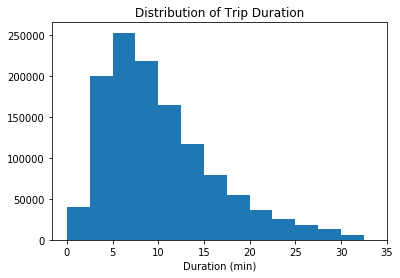

```python
bins = np.arange(0, df['duration_min'].max()+2.5, 2.5)
plt.hist(df['duration_min'], bins=bins);
plt.xticks(np.arange(0, df['duration_min'].max()+5, 5), rotation=0);
plt.xlabel('Duration (min)');
plt.title('Distribution of Trip Duration');
```

## Trips Count by User Type

Most of the trips are coming from Subscribers. Would the Subscribers and Customers have different ride behaviors? This deserves a deeper look.

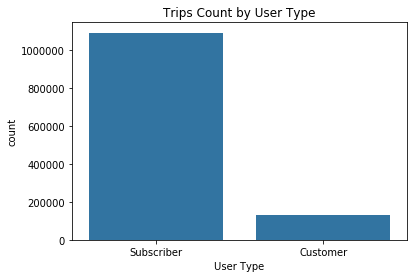

```python
default_color = sb.color_palette()[0]
sb.countplot(data=df, x='user_type', color=default_color);
plt.xlabel('User Type')
plt.title('Trips Count by User Type');
```

## Trip Duration vs User Type

I would assume that Subscribers use the bike for short distance commute; customers use the bike for commute, fun, leisure, all different kinds of purpose.

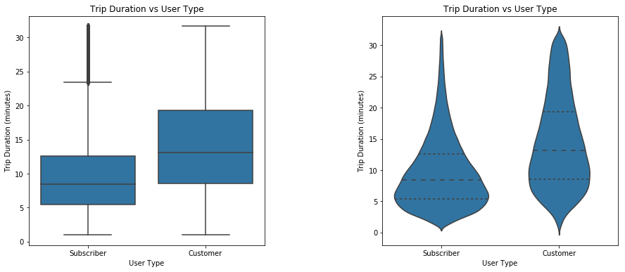

```python
plt.figure(figsize=(15,6))
plt.subplot(1,2,1)
sb.boxplot(data=df, x='user_type', y='duration_min', color=default_color);
plt.xlabel('User Type')
plt.ylabel('Trip Duration (minutes)')
plt.title('Trip Duration vs User Type');

plt.subplot(1,2,2)
sb.violinplot(data=df, x='user_type', y='duration_min', color=default_color, inner='quartile');
plt.subplots_adjust(wspace=0.5);
plt.xlabel('User Type')
plt.ylabel('Trip Duration (minutes)')
plt.title('Trip Duration vs User Type');
```

## Trip Duration vs User Age

Again, we can see that the most common trip duration is between 5 – 10 minutes. We also learn that most of trips are from 23 – 38 years old users.  
The number of trips decreases with trip duration increases, and user age increases.

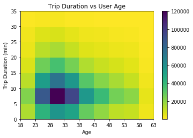

```python
bins_x = np.arange(18, df['age'].max()+5, 5)
bins_y = np.arange(0, df['duration_min'].max()+5, 5)
plt.hist2d(data=df, x='age', y='duration_min', cmap='viridis_r', cmin=0.5, bins=[bins_x, bins_y])
plt.xlabel('Age')
plt.ylabel('Trip Duration (min)')
plt.xticks(np.arange(18, df['age'].max()+5, 5));
plt.yticks(np.arange(0, df['duration_min'].max()+5, 5));
plt.title('Trip Duration vs User Age')

plt.colorbar();
```

## Trips at different Time by User Type

For the Subscriber group, the distribution of time of day is bimodal, with peaks at 8 - 9am and 5 - 6pm. There are more trips in workdays than weekends. These information supports my previous assumption that majority of Subscribers use bike for commute.

For the Customer group, there is no obvious peak in the distribution of time of day. The number of trips in different days of week falls into a uniform distribution. These information implies that Customers use the bike for different purposes.

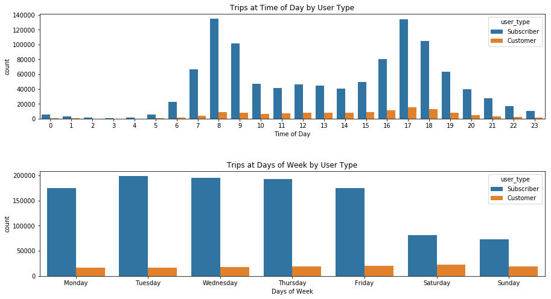

```python
plt.figure(figsize=(15,8))

plt.subplot(2,1,1)
sb.countplot(data=df, x='time_day', hue='user_type');
plt.xlabel('Time of Day')
plt.title('Trips at Time of Day by User Type')

plt.subplot(2,1,2)
sb.countplot(data=df, x='weekday', hue='user_type');
plt.xlabel('Days of Week');
plt.title('Trips at Days of Week by User Type');
plt.subplots_adjust(hspace=0.5);
```

## Trips at different Time by Days of Week

The mean trip duration is generally higher during weekends than workdays. This trend is a bit noisy from 0am to 8am.

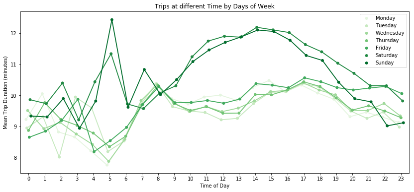

```python
plt.figure(figsize=(14,6))
sb.set_context(rc={"lines.linewidth": 1})
sb.pointplot(data=df, x='time_day', y='duration_min', hue='weekday', dodge=0.3,ci=None, palette = 'Greens')
plt.ylabel('Mean Trip Duration (minutes)');
plt.xlabel('Time of Day')
plt.title('Trips at different Time by Days of Week')
plt.legend(loc='best', bbox_to_anchor=(1, 1));
```